# Multi-Sample Multi-condition Cell-Cell Communication Analysis via NicheNet: HNSCC application; All-vs-All

Robin Browaeys 2021-04-09

In this vignette, you can learn how to perform an all-vs-all MultiNicheNet analysis. In this vignette, we start from two SingleCellExperiment objects: one SingleCellExperiment object containing the sender cell types, and one SingleCellExperiment object with receiver cell types. (for demonstration purposes, we start from the same object, that we then split based on sender/receiver cell type)

A MultiNicheNet analysis can be performed if you have multi-sample, multi-group single-cell data. MultiNicheNet will look for cell-cell communication between the cell types in your data for each sample, and compare the cell-cell communication patterns between the groups of interest. Therefore, the absolute minimum of meta data you need to have, are following columns indicating for each cell: the **group**, **sample** and **cell type**.

As example expression data of interacting cells, we will use data from Puram et al. to explore intercellular communication in the tumor microenvironment in head and neck squamous cell carcinoma (HNSCC) [See @puram_single-cell_2017]

[figure not shown]

. More specifically, we will look at differential cell-cell communication patterns between tumors scoring high for a partial epithelial-mesenschymal transition (p-EMT) program vs low-scoring tumors.

In this vignette, we will prepare the data and analysis parameters, and then perform the MultiNicheNet analysis.

The different steps of the MultiNicheNet analysis are the following:

- 0. Preparation of the analysis: load packages, NicheNet LR network & ligand-target matrix, single-cell expression data, and define main settings of the MultiNicheNet analysis
- 1. Extract cell type abundance and expression information from receiver and sender cell types, and link this expression information for ligands of the sender cell types to the corresponding receptors of the receiver cell types
- 2. Perform genome-wide differential expression analysis of receiver and sender cell types to define DE genes between the conditions of interest. Based on this analysis, we can define the logFC/p-value of ligands in senders and receptors in receivers, and define the set of affected target genes in the receiver.
- 3. Predict NicheNet ligand activities and NicheNet ligand-target links based on these differential expression results
- 4. Use the information collected above to prioritize all sender-ligand—receiver-receptor pairs.
- 5. Optional: unsupervised analysis of sender-ligand—receiver-receptor pair expression values per sample, to see heterogeneity in cell-cell communication.

In this vignette, we will demonstrate all these steps in detail.

After the MultiNicheNet analysis is done, we will explore the output of the analysis with different ways of visualization.

# Step 0: Preparation of the analysis: load packages, NicheNet LR network & ligand-target matrix, single-cell expression data

## Step 0.1: Load required packages and NicheNet ligand-receptor network and ligand-target matrix

```r
library(dplyr)
library(ggplot2)
library(multinichenetr)
```

```r
# LR network
lr_network = readRDS(url("https://zenodo.org/record/3260758/files/lr_network.rds"))
lr_network = lr_network %>% filter(! database %in% c("ppi_prediction","ppi_prediction_go")) # We filter out these interactions because they are not really bona-fide LR pairs - NicheNet v2 prior models will be released relatively soon
lr_network = lr_network %>% dplyr::rename(ligand = from, receptor = to) %>% distinct(ligand, receptor)
```

```r
ligand_target_matrix = readRDS(url("https://zenodo.org/record/3260758/files/ligand_target_matrix.rds"))
```

## Step 0.2: Prepare SingleCellExperiment objects for Sender and Receiver cells

In this vignette, sender and receiver cell types are in the same SingleCellExperiment object, which we will load here.

In this case study, we want to study differences in cell-cell communication patterns between pEMT-high and pEMT-low tumors. The meta data columns that indicate the pEMT status of tumors are ‘pEMT’ and ‘pEMT_fine’, cell type is indicated in the ‘celltype’ column, and the sample is indicated by the ‘tumor’ column.

### Malignant cells as receiver

If you start from a Seurat object, you can convert it easily to a SingleCellExperiment via `sce = Seurat::as.SingleCellExperiment(seurat_obj, assay = "RNA")`.

**User adaptation required**

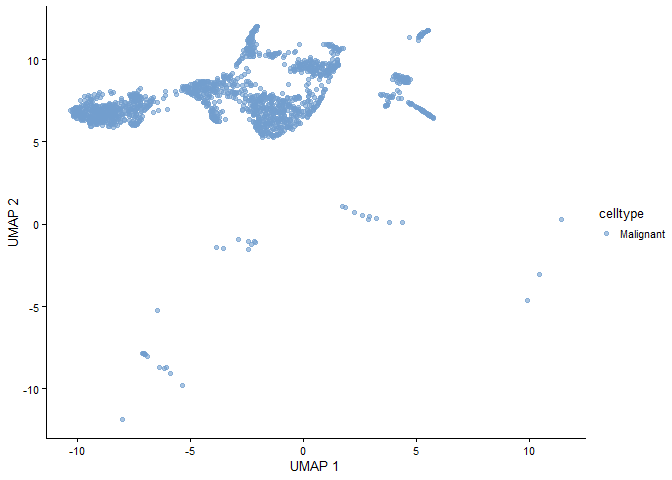

```r
sce = readRDS(url("https://zenodo.org/record/5196144/files/sce_hnscc.rds"))
sce$pEMT_fine = factor(sce$pEMT_fine, levels = c("High","Medium","Low"))

celltype_id_receiver = "celltype"
sce_receiver = sce[, SummarizedExperiment::colData(sce)[,celltype_id_receiver] == "Malignant"]

scater::plotReducedDim(sce_receiver, dimred = "UMAP", colour_by = "celltype")
```

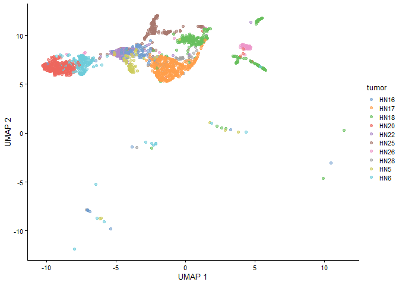

```r
scater::plotReducedDim(sce_receiver, dimred = "UMAP", colour_by = "tumor")
```

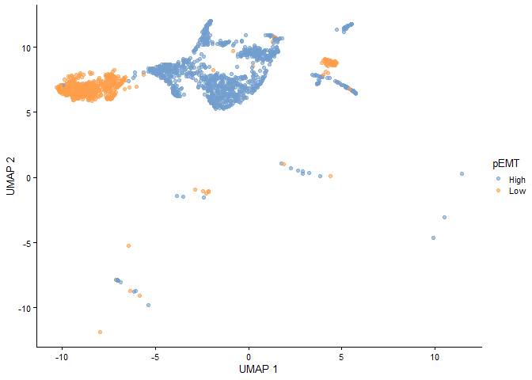

```r
scater::plotReducedDim(sce_receiver, dimred = "UMAP", colour_by = "pEMT")
```

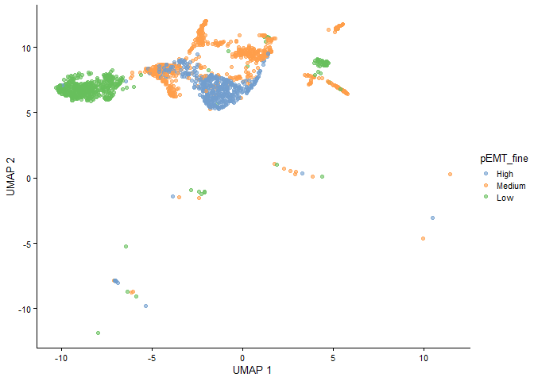

```r
scater::plotReducedDim(sce_receiver, dimred = "UMAP", colour_by = "pEMT_fine")
```

We will now also check the number of cells per cell type condition combination, and the number of patients per condition.

**User adaptation required**

```r
table(SummarizedExperiment::colData(sce_receiver)$celltype, SummarizedExperiment::colData(sce_receiver)$tumor) # cell types vs samples
##
##             HN16 HN17 HN18 HN20 HN22 HN25 HN26 HN28 HN5 HN6
##   Malignant   82  353  263  331  123  153   61   49  70 157
table(SummarizedExperiment::colData(sce_receiver)$celltype, SummarizedExperiment::colData(sce_receiver)$pEMT_fine) # cell types vs conditions
##
##             High Medium Low
##   Malignant  435    658 549
table(SummarizedExperiment::colData(sce_receiver)$tumor, SummarizedExperiment::colData(sce_receiver)$pEMT_fine) # samples vs conditions
##
##        High Medium Low
##   HN16   82      0   0
##   HN17  353      0   0
##   HN18    0    263   0
##   HN20    0      0 331
##   HN22    0    123   0
##   HN25    0    153   0
##   HN26    0      0  61
##   HN28    0     49   0
##   HN5     0     70   0
##   HN6     0      0 157
```

### Non-Malignant cells as sender

**User adaptation required**

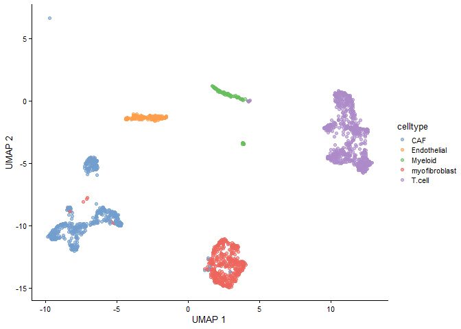

```r
getwd()
## [1] "C:/Users/rbrowaey/work/Research/NicheNet/multinichenetr/vignettes"

celltype_id_sender = "celltype"
sce_sender = sce[, SummarizedExperiment::colData(sce)[,celltype_id_sender] != "Malignant"]

scater::plotReducedDim(sce_sender, dimred = "UMAP", colour_by = "celltype")
```

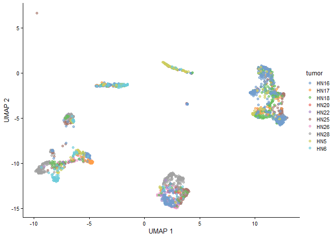

```r
scater::plotReducedDim(sce_sender, dimred = "UMAP", colour_by = "tumor")
```

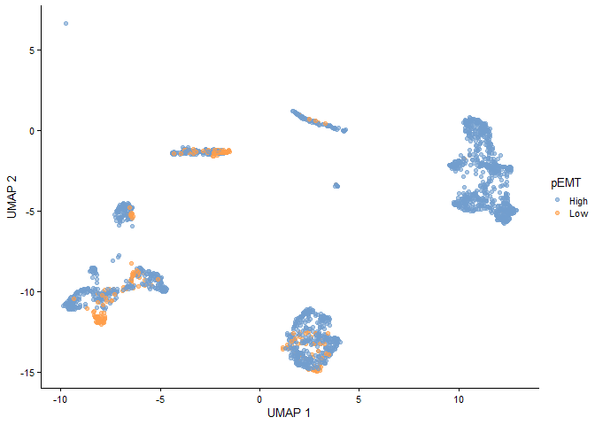

```r
scater::plotReducedDim(sce_sender, dimred = "UMAP", colour_by = "pEMT")
```

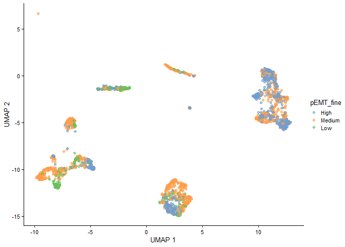

```r
scater::plotReducedDim(sce_sender, dimred = "UMAP", colour_by = "pEMT_fine")
```

We will now also check the number of cells per cell type condition combination, and the number of patients per condition.

**User adaptation required**

```r
table(SummarizedExperiment::colData(sce_sender)$celltype, SummarizedExperiment::colData(sce_sender)$tumor) # cell types vs samples
##
##                 HN16 HN17 HN18 HN20 HN22 HN25 HN26 HN28 HN5 HN6
##   CAF             47   37   36    3    9   73   19  157  37  82
##   Endothelial     43   17   18    1    1    1    0   14  11  52
##   Myeloid         15    2    7    0    1    8    1    1  58   6
##   myofibroblast   84    6   14   10   45   88   45  140   5   6
##   T.cell         300   61  207    0    0   93    3    0  28   0
table(SummarizedExperiment::colData(sce_sender)$celltype, SummarizedExperiment::colData(sce_sender)$pEMT_fine) # cell types vs conditions
##
##                 High Medium Low
##   CAF             84    312 104
##   Endothelial     60     45  53
##   Myeloid         17     75   7
##   myofibroblast   90    292  61
##   T.cell         361    328   3
table(SummarizedExperiment::colData(sce_sender)$tumor, SummarizedExperiment::colData(sce_sender)$pEMT_fine) # samples vs conditions
##
##        High Medium Low
##   HN16  489      0   0
##   HN17  123      0   0
##   HN18    0    282   0
##   HN20    0      0  14
##   HN22    0     56   0
##   HN25    0    263   0
##   HN26    0      0  68
##   HN28    0    312   0
##   HN5     0    139   0
##   HN6     0      0 146
```

As you can see, some Celltype-Sample combinations have 0 cells. It is possible that during DE analysis, some cell types will be removed from the analysis if there is not enough information to do a DE analysis. (More info later)

## Step 0.3: Prepare settings of the MultiNicheNet cell-cell communication analysis

### Define in which metadata columns we can find the **group**, **sample** and **cell type** IDs

For the group_id, we now choose for the ‘pEMT_fine’ column instead of ‘pEMT’, which we selected in the analysis of the other vignette.

**User adaptation required**

```r
sample_id = "tumor"
group_id = "pEMT_fine"
```

```r
senders_oi = SummarizedExperiment::colData(sce_sender)[,celltype_id_sender] %>% unique()
receivers_oi = SummarizedExperiment::colData(sce_receiver)[,celltype_id_receiver] %>% unique()
```

Now we will go to the first real step of the MultiNicheNet analysis

# Step 1: Extract cell type abundance and expression information from receiver and sender cell types, and link this expression information for ligands of the sender cell types to the corresponding receptors of the receiver cell types

Since MultiNicheNet will infer group differences at the sample level for each cell type (currently via Muscat and pseudobulking), we need to have sufficient cells per sample of a cell type, and this for both groups. In the following analysis we will set this minimum number of cells per cell type per sample at 5. For 10x scRNAseq datasets, we recommend to set this to 10.

**User adaptation recommended**

```r
min_cells = 5
```

Now we will calculate abundance and expression information for each cell type / sample / group combination with the following functions. In the output of this function, you can also find some ‘Cell type abundance diagnostic plots’ that will the users which celltype-sample combinations will be left out later on for DE calculation because the nr of cells is lower than de defined minimum defined here above. If too many celltype-sample combinations don’t pass this threshold, we recommend to define your cell types in a more general way (use one level higher of the cell type ontology hierarchy) (eg TH17 CD4T cells –> CD4T cells).

```r
abundance_expression_info = get_abundance_expression_info_separate(sce_receiver = sce_receiver, sce_sender = sce_sender, sample_id = sample_id, group_id = group_id, celltype_id_receiver = celltype_id_receiver, celltype_id_sender = celltype_id_sender, senders_oi = senders_oi, receivers_oi = receivers_oi, lr_network = lr_network, covariates = covariates, min_cells = min_cells)
```

First, check the cell type abundance diagnostic plots.

### Interpretation of cell type abundance information

The first plot visualizes the number of cells per celltype-sample combination, and indicates which combinations are removed during the DE analysis because there are less than `min_cells` in the celltype-sample combination.

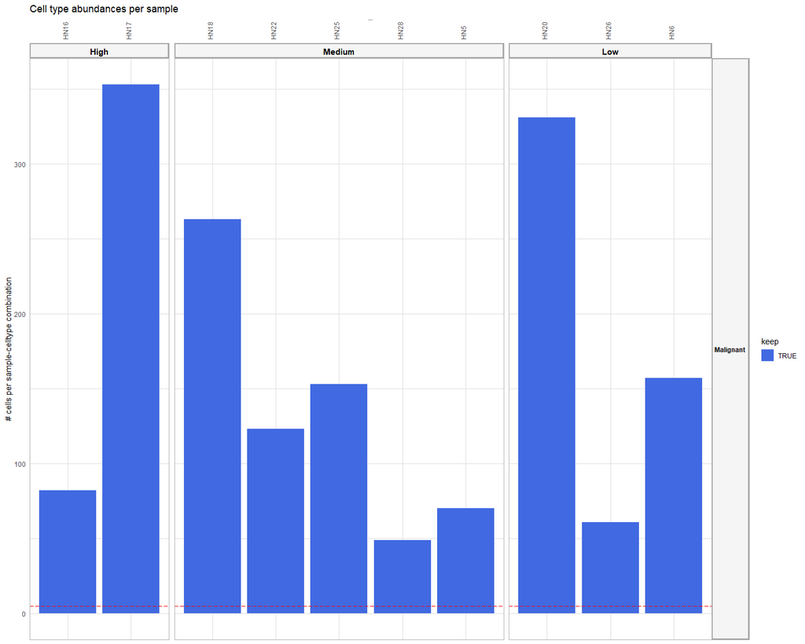

```r
abundance_expression_info$abund_plot_sample_receiver
```

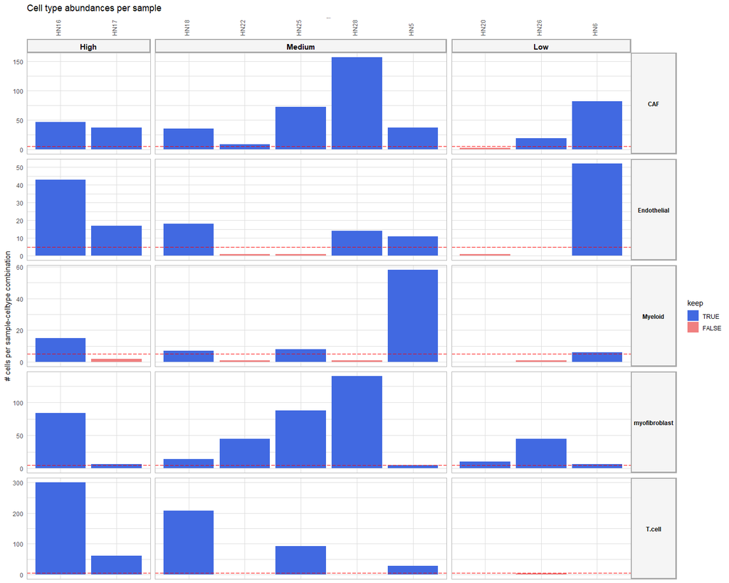

```r
abundance_expression_info$abund_plot_sample_sender
```

In a next plot, we will look at differential abundance between the conditions. This because the pseudobulking approach behind Muscat could potentially suffer from some biases if there would be huge differences in abundances of a cell type between different groups. Downstream results of these cell types should then be considered with some caution.

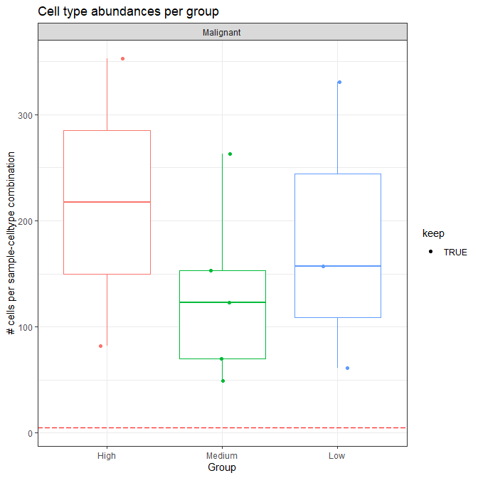

```r
abundance_expression_info$abund_plot_group_receiver
```

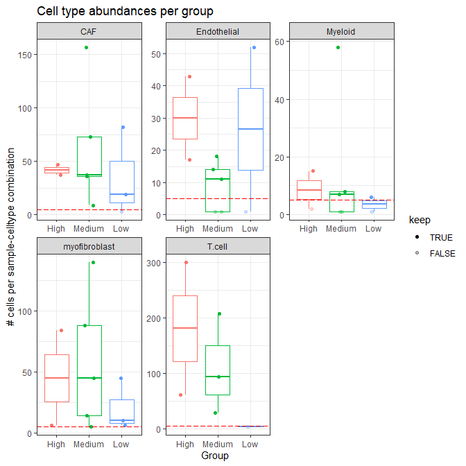

```r
abundance_expression_info$abund_plot_group_sender
```

Differential abundance looks quite OK for the cell types kept for the DE analysis (i.e. CAF, Malignant and myofibroblast)

If you want to look at the cell numbers behind these plots, you can do so via the following piece of code

```r
abundance_expression_info$abundance_data_receiver
## # A tibble: 10 x 5
## # Groups:   sample, receiver [10]
##    sample receiver  n_cells_receiver group  keep_receiver
##    <chr>  <chr>                <int> <fct>          <dbl>
##  1 HN16   Malignant               82 High               1
##  2 HN17   Malignant              353 High               1
##  3 HN18   Malignant              263 Medium             1
##  4 HN20   Malignant              331 Low                1
##  5 HN22   Malignant              123 Medium             1
##  6 HN25   Malignant              153 Medium             1
##  7 HN26   Malignant               61 Low                1
##  8 HN28   Malignant               49 Medium             1
##  9 HN5    Malignant               70 Medium             1
## 10 HN6    Malignant              157 Low                1
abundance_expression_info$abundance_data_sender # in the case of an all-vs-all analysis: both are the same
## # A tibble: 44 x 5
## # Groups:   sample, sender [44]
##    sample sender        n_cells_sender group keep_sender
##    <chr>  <chr>                  <int> <fct>       <dbl>
##  1 HN16   CAF                       47 High            1
##  2 HN16   Endothelial               43 High            1
##  3 HN16   Myeloid                   15 High            1
##  4 HN16   myofibroblast             84 High            1
##  5 HN16   T.cell                   300 High            1
##  6 HN17   CAF                       37 High            1
##  7 HN17   Endothelial               17 High            1
##  8 HN17   Myeloid                    2 High            0
##  9 HN17   myofibroblast              6 High            1
## 10 HN17   T.cell                    61 High            1
## # ... with 34 more rows
```

**Important**: Based on the cell type abundance diagnostics, we recommend users to change their analysis settings if required, before proceeding with the rest of the analysis.

### Interpretation of expression information

Previously, we also calculated expression information. With the following piece of code, you can check the average expression for each gene per sample (normalized expression value and fraction of expressing cells with non-zero counts).

```r
abundance_expression_info$receiver_info$avg_df
## # A tibble: 207,510 x 4
##    gene         sample average_sample celltype
##    <chr>        <chr>           <dbl> <fct>
##  1 C9orf152     HN26           0      Malignant
##  2 RPS11        HN26           2.91   Malignant
##  3 ELMO2        HN26           0.434  Malignant
##  4 CREB3L1      HN26           0.0733 Malignant
##  5 PNMA1        HN26           0.575  Malignant
##  6 MMP2         HN26           0.0345 Malignant
##  7 TMEM216      HN26           0.458  Malignant
##  8 TRAF3IP2-AS1 HN26           0.404  Malignant
##  9 LRRC37A5P    HN26           0      Malignant
## 10 LOC653712    HN26           0.164  Malignant
## # ... with 207,500 more rows
abundance_expression_info$receiver_info$frq_df
## # A tibble: 207,510 x 4
##    gene         sample fraction_sample celltype
##    <chr>        <chr>            <dbl> <chr>
##  1 C9orf152     HN26            0      Malignant
##  2 RPS11        HN26            0.967  Malignant
##  3 ELMO2        HN26            0.262  Malignant
##  4 CREB3L1      HN26            0.0820 Malignant
##  5 PNMA1        HN26            0.230  Malignant
##  6 MMP2         HN26            0.0328 Malignant
##  7 TMEM216      HN26            0.197  Malignant
##  8 TRAF3IP2-AS1 HN26            0.689  Malignant
##  9 LRRC37A5P    HN26            0      Malignant
## 10 LOC653712    HN26            0.230  Malignant
## # ... with 207,500 more rows

abundance_expression_info$sender_info$avg_df
## # A tibble: 1,037,550 x 4
##    gene         sample average_sample celltype
##    <chr>        <chr>           <dbl> <fct>
##  1 C9orf152     HN28           0      myofibroblast
##  2 RPS11        HN28           2.67   myofibroblast
##  3 ELMO2        HN28           0.276  myofibroblast
##  4 CREB3L1      HN28           0      myofibroblast
##  5 PNMA1        HN28           0.580  myofibroblast
##  6 MMP2         HN28           0.0636 myofibroblast
##  7 TMEM216      HN28           0.0891 myofibroblast
##  8 TRAF3IP2-AS1 HN28           0.589  myofibroblast
##  9 LRRC37A5P    HN28           0      myofibroblast
## 10 LOC653712    HN28           0.0747 myofibroblast
## # ... with 1,037,540 more rows
abundance_expression_info$sender_info$frq_df
## # A tibble: 1,037,550 x 4
##    gene         sample fraction_sample celltype
##    <chr>        <chr>            <dbl> <chr>
##  1 C9orf152     HN28            0      myofibroblast
##  2 RPS11        HN28            0.957  myofibroblast
##  3 ELMO2        HN28            0.157  myofibroblast
##  4 CREB3L1      HN28            0      myofibroblast
##  5 PNMA1        HN28            0.243  myofibroblast
##  6 MMP2         HN28            0.05   myofibroblast
##  7 TMEM216      HN28            0.0429 myofibroblast
##  8 TRAF3IP2-AS1 HN28            0.593  myofibroblast
##  9 LRRC37A5P    HN28            0      myofibroblast
## 10 LOC653712    HN28            0.0929 myofibroblast
## # ... with 1,037,540 more rows
```

Now for the average per group:

```r
abundance_expression_info$receiver_info$avg_df_group
## # A tibble: 62,253 x 4
## # Groups:   group, celltype [3]
##    group celltype  gene     average_group
##    <fct> <fct>     <chr>            <dbl>
##  1 High  Malignant A1BG           0.121
##  2 High  Malignant A1BG-AS1       0.0193
##  3 High  Malignant A1CF           0.00430
##  4 High  Malignant A2M            0.147
##  5 High  Malignant A2M-AS1        0.00216
##  6 High  Malignant A2ML1          0.101
##  7 High  Malignant A2MP1          0
##  8 High  Malignant A4GALT         0.176
##  9 High  Malignant A4GNT          0
## 10 High  Malignant AAAS           0.698
## # ... with 62,243 more rows
abundance_expression_info$receiver_info$frq_df_group
## # A tibble: 62,253 x 4
## # Groups:   group, celltype [3]
##    group celltype  gene     fraction_group
##    <fct> <chr>     <chr>             <dbl>
##  1 High  Malignant A1BG            0.0719
##  2 High  Malignant A1BG-AS1        0.0179
##  3 High  Malignant A1CF            0.103
##  4 High  Malignant A2M             0.120
##  5 High  Malignant A2M-AS1         0.00142
##  6 High  Malignant A2ML1           0.249
##  7 High  Malignant A2MP1           0
##  8 High  Malignant A4GALT          0.143
##  9 High  Malignant A4GNT           0
## 10 High  Malignant AAAS            0.352
## # ... with 62,243 more rows

abundance_expression_info$sender_info$avg_df_group
## # A tibble: 311,265 x 4
## # Groups:   group, celltype [15]
##    group celltype gene     average_group
##    <fct> <fct>    <chr>            <dbl>
##  1 High  CAF      A1BG           0.241
##  2 High  CAF      A1BG-AS1       0.0573
##  3 High  CAF      A1CF           0.00447
##  4 High  CAF      A2M            1.07
##  5 High  CAF      A2M-AS1        0.0331
##  6 High  CAF      A2ML1          0.0269
##  7 High  CAF      A2MP1          0
##  8 High  CAF      A4GALT         0.252
##  9 High  CAF      A4GNT          0
## 10 High  CAF      AAAS           0.121
## # ... with 311,255 more rows
abundance_expression_info$sender_info$frq_df_group
## # A tibble: 311,265 x 4
## # Groups:   group, celltype [15]
##    group celltype gene     fraction_group
##    <fct> <chr>    <chr>             <dbl>
##  1 High  CAF      A1BG             0.179
##  2 High  CAF      A1BG-AS1         0.0426
##  3 High  CAF      A1CF             0.0589
##  4 High  CAF      A2M              0.489
##  5 High  CAF      A2M-AS1          0.0426
##  6 High  CAF      A2ML1            0.174
##  7 High  CAF      A2MP1            0
##  8 High  CAF      A4GALT           0.152
##  9 High  CAF      A4GNT            0
## 10 High  CAF      AAAS             0.0561
## # ... with 311,255 more rows
```

In the last part of this step, we combined this information for each ligand-receptor pair combination for each sender-receiver combination. The output of this can be seen as well:

For sample-based:

```r
abundance_expression_info$sender_receiver_info$avg_df
## # A tibble: 60,300 x 8
##    sample sender        receiver  ligand receptor avg_ligand avg_receptor ligand_receptor_prod
##    <chr>  <fct>         <fct>     <chr>  <chr>         <dbl>        <dbl>                <dbl>
##  1 HN17   CAF           Malignant COL1A1 ITGB1          3.43         2.72                 9.34
##  2 HN17   CAF           Malignant COL1A1 SDC1           3.43         2.53                 8.69
##  3 HN17   myofibroblast Malignant COL1A1 ITGB1          3.17         2.72                 8.61
##  4 HN17   CAF           Malignant COL1A1 CD44           3.43         2.34                 8.02
##  5 HN17   myofibroblast Malignant COL1A1 SDC1           3.17         2.53                 8.01
##  6 HN20   CAF           Malignant COL1A1 SDC1           3.22         2.42                 7.78
##  7 HN17   myofibroblast Malignant COL1A1 CD44           3.17         2.34                 7.39
##  8 HN20   CAF           Malignant FN1    SDC1           2.85         2.42                 6.89
##  9 HN16   CAF           Malignant COL1A1 ITGB1          2.60         2.63                 6.83
## 10 HN17   Myeloid       Malignant ADAM17 ITGB1          2.51         2.72                 6.82
## # ... with 60,290 more rows
abundance_expression_info$sender_receiver_info$frq_df
## # A tibble: 60,300 x 8
##    sample sender        receiver  ligand receptor fraction_ligand fraction_receptor ligand_receptor_fraction_prod
##    <chr>  <chr>         <chr>     <chr>  <chr>              <dbl>             <dbl>                         <dbl>
##  1 HN28   Myeloid       Malignant COL1A1 CD44                   1             1                             1
##  2 HN28   Myeloid       Malignant LAMA2  RPSA                   1             1                             1
##  3 HN28   Myeloid       Malignant FN1    CD44                   1             1                             1
##  4 HN28   Myeloid       Malignant HAS2   CD44                   1             1                             1
##  5 HN28   Myeloid       Malignant LAMC3  CD44                   1             1                             1
##  6 HN28   Myeloid       Malignant LAMB2  RPSA                   1             1                             1
##  7 HN20   Endothelial   Malignant F11R   F11R                   1             0.997                         0.997
##  8 HN17   myofibroblast Malignant THBS1  SDC1                   1             0.994                         0.994
##  9 HN17   myofibroblast Malignant COL1A1 ITGB1                  1             0.994                         0.994
## 10 HN17   myofibroblast Malignant COL1A1 SDC1                   1             0.994                         0.994
## # ... with 60,290 more rows
```

For group-based:

```r
abundance_expression_info$sender_receiver_info$avg_df_group
## # A tibble: 18,090 x 8
## # Groups:   group, sender [15]
##    group sender        receiver  ligand receptor avg_ligand_group avg_receptor_group ligand_receptor_prod_group
##    <fct> <fct>         <fct>     <chr>  <chr>               <dbl>              <dbl>                      <dbl>
##  1 High  CAF           Malignant COL1A1 ITGB1                3.02               2.67                       8.07
##  2 High  CAF           Malignant COL1A1 SDC1                 3.02               2.26                       6.81
##  3 High  CAF           Malignant COL1A1 CD44                 3.02               2.17                       6.56
##  4 High  myofibroblast Malignant COL1A1 ITGB1                2.34               2.67                       6.25
##  5 Low   CAF           Malignant COL1A1 SDC1                 2.75               2.22                       6.11
##  6 High  Endothelial   Malignant CD99   CD99                 2.32               2.43                       5.64
##  7 High  myofibroblast Malignant THBS1  SDC1                 2.46               2.26                       5.55
##  8 High  Endothelial   Malignant COL4A1 ITGB1                2.04               2.67                       5.46
##  9 Low   CAF           Malignant COL1A1 CD44                 2.75               1.96                       5.39
## 10 High  CAF           Malignant FN1    ITGB1                2.01               2.67                       5.36
## # ... with 18,080 more rows
abundance_expression_info$sender_receiver_info$frq_df_group
## # A tibble: 18,090 x 8
## # Groups:   group, sender [15]
##    group sender        receiver  ligand receptor fraction_ligand_group fraction_receptor_group ligand_receptor_fraction_prod_group
##    <fct> <chr>         <chr>     <chr>  <chr>                    <dbl>                   <dbl>                               <dbl>
##  1 High  Myeloid       Malignant F11R   F11R                     1                       0.981                               0.981
##  2 High  CAF           Malignant COL1A1 ITGB1                    0.957                   0.979                               0.937
##  3 High  myofibroblast Malignant THBS1  CD47                     0.976                   0.939                               0.917
##  4 High  CAF           Malignant COL1A1 CD44                     0.957                   0.953                               0.913
##  5 High  T.cell        Malignant F11R   F11R                     0.924                   0.981                               0.906
##  6 High  Endothelial   Malignant F11R   F11R                     0.906                   0.981                               0.889
##  7 Low   CAF           Malignant HLA-E  KLRD1                    0.970                   0.912                               0.885
##  8 High  Endothelial   Malignant HLA-E  KLRD1                    1                       0.876                               0.876
##  9 High  Myeloid       Malignant HLA-E  KLRD1                    1                       0.876                               0.876
## 10 Low   CAF           Malignant COL1A1 SDC1                     0.972                   0.902                               0.876
## # ... with 18,080 more rows
```

# Step 2: Perform genome-wide differential expression analysis of receiver and sender cell types to define DE genes between the conditions of interest. Based on this analysis, we can define the logFC/p-value of ligands in senders and receptors in receivers, and define the set of affected target genes in the receiver.

Now we will go over to the multi-group, multi-sample differential expression (DE) analysis (also called ‘differential state’ analysis by the developers of Muscat).

### Define the contrasts and covariates of interest for the DE analysis.

Note the format to indicate the contrasts! (This formatting should be adhered to very strictly, and white spaces are not allowed)

**User adaptation required**

```r
covariates = NA
contrasts_oi = c("'High-(Medium+Low)/2','Medium-(High+Low)/2','Low-(Medium+High)/2'") # no spaces between the different contrasts!
contrast_tbl = tibble(contrast =
                        c("High-(Medium+Low)/2", "Medium-(High+Low)/2","Low-(Medium+High)/2"),  # division by 2 necessary because 2 groups to compare against !!
                      group = c("High","Medium","Low"))
min_cells = 5 # here 5 for demonstration purposes - but recommended default is 10.
```

### Perform the DE analysis for each cell type.

```r
DE_info_receiver = get_DE_info(sce = sce_receiver, sample_id = sample_id, group_id = group_id, celltype_id = celltype_id_receiver, covariates = covariates, contrasts_oi = contrasts_oi, min_cells = min_cells)
```

```r
DE_info_sender = get_DE_info(sce = sce_sender, sample_id = sample_id, group_id = group_id, celltype_id = celltype_id_sender, covariates = covariates, contrasts_oi = contrasts_oi, min_cells = min_cells)
## [1] "excluded cell types are:"
## [1] "Endothelial" "Myeloid"     "T.cell"
## [1] "These celltypes are not considered in the analysis. After removing samples that contain less cells than the required minimal, some groups don't have 2 or more samples anymore. As a result the analysis cannot be run. To solve this: decrease the number of min_cells or change your group_id and pool all samples that belong to groups that are not of interest! "
```

### Check DE results

Table with logFC and p-values for each gene-celltype-contrast:

```r
DE_info_receiver$celltype_de$de_output_tidy
## # A tibble: 44,481 x 9
##    gene         cluster_id   logFC logCPM       F  p_val p_adj.loc p_adj contrast
##    <chr>        <chr>        <dbl>  <dbl>   <dbl>  <dbl>     <dbl> <dbl> <chr>
##  1 RPS11        Malignant  -0.0106   8.91 0.00475 0.946      0.992 0.992 High-(Medium+Low)/2
##  2 ELMO2        Malignant   0.0411   5.81 0.0107  0.919      0.987 0.987 High-(Medium+Low)/2
##  3 CREB3L1      Malignant  -6.2      2.78 4.77    0.0505     0.59  0.59  High-(Medium+Low)/2
##  4 PNMA1        Malignant  -0.91     5.83 1.99    0.185      0.74  0.74  High-(Medium+Low)/2
##  5 MMP2         Malignant   1.69     6.33 6.54    0.0258     0.536 0.536 High-(Medium+Low)/2
##  6 TMEM216      Malignant  -0.393    5.9  0.607   0.452      0.869 0.869 High-(Medium+Low)/2
##  7 TRAF3IP2-AS1 Malignant  -0.333    4.39 0.515   0.487      0.884 0.884 High-(Medium+Low)/2
##  8 LOC653712    Malignant   0.839    2.79 1.13    0.309      0.808 0.808 High-(Medium+Low)/2
##  9 ZHX3         Malignant   0.0272   3.75 0.0028  0.959      0.994 0.994 High-(Medium+Low)/2
## 10 ERCC5        Malignant   0.385    5.6  1.11    0.313      0.809 0.809 High-(Medium+Low)/2
## # ... with 44,471 more rows
```

```r
DE_info_sender$celltype_de$de_output_tidy
## # A tibble: 58,119 x 9
##    gene         cluster_id   logFC logCPM       F p_val p_adj.loc p_adj contrast
##    <chr>        <chr>        <dbl>  <dbl>   <dbl> <dbl>     <dbl> <dbl> <chr>
##  1 RPS11        CAF        -0.0696   9.29 0.0663  0.8       0.958 0.974 High-(Medium+Low)/2
##  2 ELMO2        CAF         0.308    6.64 0.439   0.518     0.885 0.941 High-(Medium+Low)/2
##  3 CREB3L1      CAF         0.319    5.45 0.0785  0.783     0.953 0.973 High-(Medium+Low)/2
##  4 PNMA1        CAF        -0.947    6.51 2.59    0.13      0.676 0.876 High-(Medium+Low)/2
##  5 MMP2         CAF         0.0535   9.28 0.0447  0.836     0.964 0.978 High-(Medium+Low)/2
##  6 TMEM216      CAF        -0.203    6    0.11    0.745     0.943 0.966 High-(Medium+Low)/2
##  7 TRAF3IP2-AS1 CAF        -0.625    5.54 0.888   0.362     0.826 0.931 High-(Medium+Low)/2
##  8 ZHX3         CAF        -0.0565   5.47 0.00652 0.937     0.985 0.99  High-(Medium+Low)/2
##  9 ERCC5        CAF        -0.0511   6.08 0.00536 0.943     0.987 0.991 High-(Medium+Low)/2
## 10 APBB2        CAF         0.193    6.47 0.158   0.697     0.929 0.961 High-(Medium+Low)/2
## # ... with 58,109 more rows
```

Diagnostic p-value histograms:

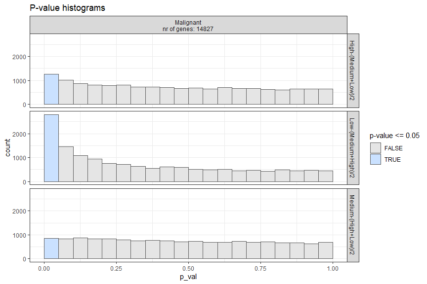

```r
DE_info_receiver$hist_pvals
```

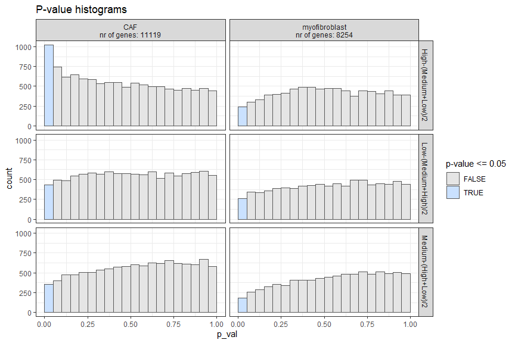

```r
DE_info_sender$hist_pvals
```

In order to trust the p-values, the p-value distributions should be uniform distributions, with a peak allowed between 0 and 0.05 if there would be a clear biological effect in the data. This clear effect (=clear DE) seems to be present here in the Malignant cell type populations, although the histogram is not very uniformly distributed for p-values between 0.05 and 0.25. This might point to issues in the DE model definition (eg we did not add all important covariates, substructure present,…)

### Empirical Null procedure

**User adaptation recommended**

```r
empirical_pval_receiver = TRUE
if(empirical_pval_receiver == TRUE){
  DE_info_emp_receiver = get_empirical_pvals(DE_info_receiver$celltype_de$de_output_tidy)
}
empirical_pval_sender = TRUE
if(empirical_pval_sender == TRUE){
  DE_info_emp_sender = get_empirical_pvals(DE_info_sender$celltype_de$de_output_tidy)
}
```

Table with logFC and p-values for each gene-celltype-contrast:

```r
DE_info_emp_receiver$de_output_tidy_emp
## # A tibble: 44,481 x 11
##    gene         cluster_id   logFC logCPM       F  p_val p_adj.loc p_adj contrast             p_emp p_adj_emp
##    <chr>        <chr>        <dbl>  <dbl>   <dbl>  <dbl>     <dbl> <dbl> <chr>                <dbl>     <dbl>
##  1 RPS11        Malignant  -0.0106   8.91 0.00475 0.946      0.992 0.992 High-(Medium+Low)/2 0.870      0.994
##  2 ELMO2        Malignant   0.0411   5.81 0.0107  0.919      0.987 0.987 High-(Medium+Low)/2 0.752      0.994
##  3 CREB3L1      Malignant  -6.2      2.78 4.77    0.0505     0.59  0.59  High-(Medium+Low)/2 0.124      0.917
##  4 PNMA1        Malignant  -0.91     5.83 1.99    0.185      0.74  0.74  High-(Medium+Low)/2 0.332      0.969
##  5 MMP2         Malignant   1.69     6.33 6.54    0.0258     0.536 0.536 High-(Medium+Low)/2 0.0255     0.766
##  6 TMEM216      Malignant  -0.393    5.9  0.607   0.452      0.869 0.869 High-(Medium+Low)/2 0.650      0.994
##  7 TRAF3IP2-AS1 Malignant  -0.333    4.39 0.515   0.487      0.884 0.884 High-(Medium+Low)/2 0.687      0.994
##  8 LOC653712    Malignant   0.839    2.79 1.13    0.309      0.808 0.808 High-(Medium+Low)/2 0.254      0.948
##  9 ZHX3         Malignant   0.0272   3.75 0.0028  0.959      0.994 0.994 High-(Medium+Low)/2 0.787      0.994
## 10 ERCC5        Malignant   0.385    5.6  1.11    0.313      0.809 0.809 High-(Medium+Low)/2 0.257      0.950
## # ... with 44,471 more rows
```

```r
DE_info_emp_sender$de_output_tidy_emp
## # A tibble: 58,119 x 11
##    gene         cluster_id   logFC logCPM       F p_val p_adj.loc p_adj contrast            p_emp p_adj_emp
##    <chr>        <chr>        <dbl>  <dbl>   <dbl> <dbl>     <dbl> <dbl> <chr>               <dbl>     <dbl>
##  1 RPS11        CAF        -0.0696   9.29 0.0663  0.8       0.958 0.974 High-(Medium+Low)/2 0.894     0.996
##  2 ELMO2        CAF         0.308    6.64 0.439   0.518     0.885 0.941 High-(Medium+Low)/2 0.528     0.987
##  3 CREB3L1      CAF         0.319    5.45 0.0785  0.783     0.953 0.973 High-(Medium+Low)/2 0.752     0.991
##  4 PNMA1        CAF        -0.947    6.51 2.59    0.13      0.676 0.876 High-(Medium+Low)/2 0.229     0.987
##  5 MMP2         CAF         0.0535   9.28 0.0447  0.836     0.964 0.978 High-(Medium+Low)/2 0.796     0.991
##  6 TMEM216      CAF        -0.203    6    0.11    0.745     0.943 0.966 High-(Medium+Low)/2 0.846     0.994
##  7 TRAF3IP2-AS1 CAF        -0.625    5.54 0.888   0.362     0.826 0.931 High-(Medium+Low)/2 0.489     0.987
##  8 ZHX3         CAF        -0.0565   5.47 0.00652 0.937     0.985 0.99  High-(Medium+Low)/2 0.988     0.999
##  9 ERCC5        CAF        -0.0511   6.08 0.00536 0.943     0.987 0.991 High-(Medium+Low)/2 0.983     0.999
## 10 APBB2        CAF         0.193    6.47 0.158   0.697     0.929 0.961 High-(Medium+Low)/2 0.680     0.988
## # ... with 58,109 more rows
```

The following plot shows those corrected, empirical p-values:

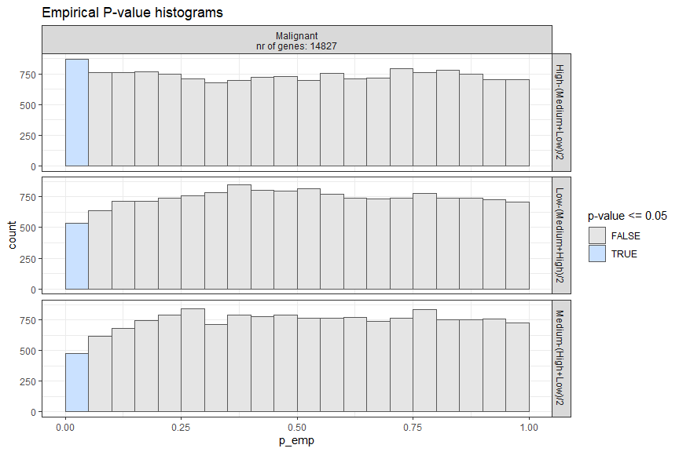

```r
DE_info_emp_receiver$hist_pvals_emp
```

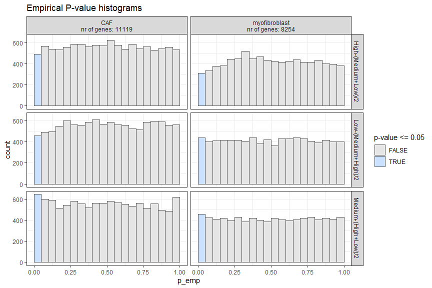

```r
DE_info_emp_sender$hist_pvals_emp
```

The following plots show how well the correction worked. The green fitted curve should fit well with the histogram. If not, this might point to some issues in the DE model definition.

**User adaptation required**

[figure not shown]

```
##
## $`CAF.Low-High`
```

[figure not shown]

```
##
## $`Malignant.High-Low`
```

[figure not shown]

```
##
## $`Malignant.Low-High`
```

[figure not shown]

```
##
## $`myofibroblast.High-Low`
```

[figure not shown]

```
##
## $`myofibroblast.Low-High`
```

[figure not shown]

```r
DE_info_emp$z_distr_plots_emp_pval
## $`CAF.High-Low`
```

In general, these plots looks fine.

As additional check, we will look for the concordance between p-values rankings of the original and empirical DE analysis (via ranking-line and upset plots):

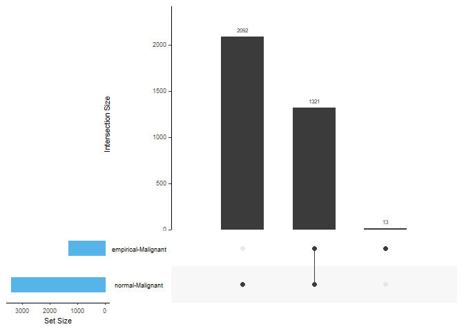

```
##
## [[1]][[2]]
```

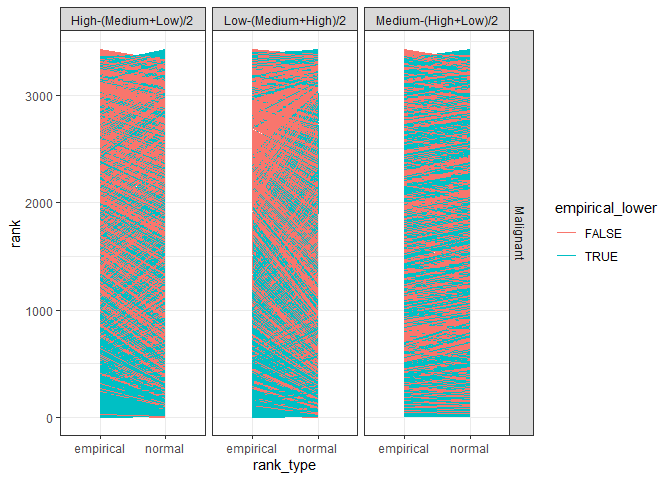

```r
comparison_plots_receivers = DE_info_receiver$celltype_de$de_output_tidy$cluster_id %>% unique() %>% lapply(function(celltype_oi, adjusted = FALSE){
  if(adjusted == TRUE){
      de_genes_normal = DE_info_receiver$celltype_de$de_output_tidy %>% filter(cluster_id == celltype_oi) %>% filter(p_adj.glb <= 0.05) %>% pull(gene) %>% unique()
      de_genes_emp = DE_info_emp_receiver$de_output_tidy_emp %>% filter(cluster_id == celltype_oi) %>% filter(p_adj_emp <= 0.05) %>% pull(gene) %>% unique()

  } else {
      de_genes_normal = DE_info_receiver$celltype_de$de_output_tidy %>% filter(cluster_id == celltype_oi) %>% filter(p_val <= 0.05) %>% pull(gene) %>% unique()
      de_genes_emp = DE_info_emp_receiver$de_output_tidy_emp %>% filter(cluster_id == celltype_oi) %>% filter(p_emp <= 0.05) %>% pull(gene) %>% unique()

  }

  upset_df = tibble(gene = union(de_genes_normal, de_genes_emp), normal = as.double(gene %in% de_genes_normal), empirical = as.double(gene %in% de_genes_emp)) %>% data.frame() %>% magrittr::set_rownames(.$gene) %>% select(-gene)
  colnames(upset_df) = paste(colnames(upset_df), celltype_oi, sep = "-")
  p_upset = UpSetR::upset(upset_df, sets.bar.color = "#56B4E9", order.by = "freq", empty.intersections = "on")

  p_ranking = DE_info_emp_receiver$de_output_tidy_emp %>% filter(gene %in% union(de_genes_normal, de_genes_emp) & cluster_id == celltype_oi) %>% group_by(cluster_id, contrast) %>% mutate(normal = rank(p_val), empirical = rank(p_emp)) %>% filter(normal != empirical) %>% mutate(empirical_lower = empirical < normal) %>% tidyr::gather(rank_type, rank, normal:empirical) %>% select(gene, rank_type, rank, empirical_lower)  %>%
    ggplot(aes(rank_type, rank, group = gene, color = empirical_lower)) + geom_line(aes(group = gene)) + facet_grid(cluster_id ~ contrast) + theme_bw()

  return(list(p_upset, p_ranking))

}, adjusted = FALSE)
comparison_plots_receivers
## [[1]]
## [[1]][[1]]
```

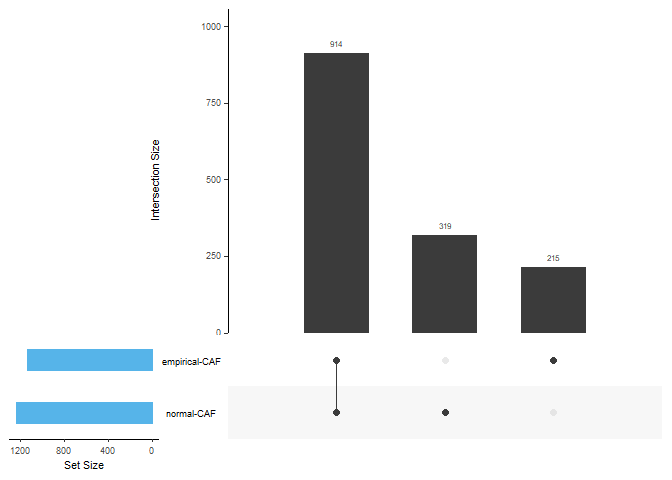

```
##
## [[1]][[2]]
```

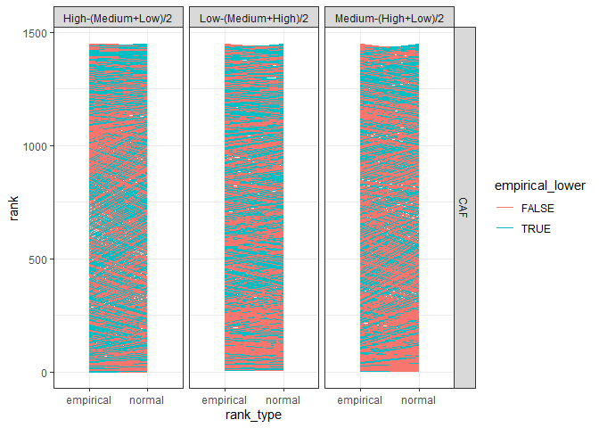

```
##
##
## [[2]]
## [[2]][[1]]
```

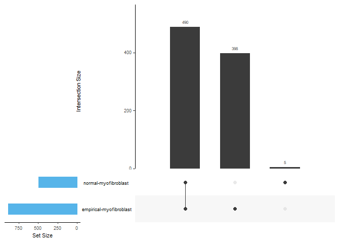

```
##
## [[2]][[2]]
```

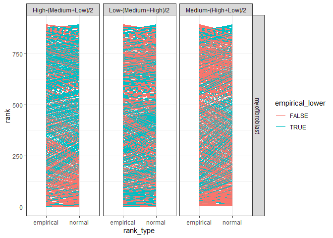

```r
comparison_plots_senders = DE_info_sender$celltype_de$de_output_tidy$cluster_id %>% unique() %>% lapply(function(celltype_oi, adjusted = FALSE){
  if(adjusted == TRUE){
      de_genes_normal = DE_info_sender$celltype_de$de_output_tidy %>% filter(cluster_id == celltype_oi) %>% filter(p_adj.glb <= 0.05) %>% pull(gene) %>% unique()
      de_genes_emp = DE_info_emp_sender$de_output_tidy_emp %>% filter(cluster_id == celltype_oi) %>% filter(p_adj_emp <= 0.05) %>% pull(gene) %>% unique()

  } else {
      de_genes_normal = DE_info_sender$celltype_de$de_output_tidy %>% filter(cluster_id == celltype_oi) %>% filter(p_val <= 0.05) %>% pull(gene) %>% unique()
      de_genes_emp = DE_info_emp_sender$de_output_tidy_emp %>% filter(cluster_id == celltype_oi) %>% filter(p_emp <= 0.05) %>% pull(gene) %>% unique()

  }

  upset_df = tibble(gene = union(de_genes_normal, de_genes_emp), normal = as.double(gene %in% de_genes_normal), empirical = as.double(gene %in% de_genes_emp)) %>% data.frame() %>% magrittr::set_rownames(.$gene) %>% select(-gene)
  colnames(upset_df) = paste(colnames(upset_df), celltype_oi, sep = "-")
  p_upset = UpSetR::upset(upset_df, sets.bar.color = "#56B4E9", order.by = "freq", empty.intersections = "on")

  p_ranking = DE_info_emp_sender$de_output_tidy_emp %>% filter(gene %in% union(de_genes_normal, de_genes_emp) & cluster_id == celltype_oi) %>% group_by(cluster_id, contrast) %>% mutate(normal = rank(p_val), empirical = rank(p_emp)) %>% filter(normal != empirical) %>% mutate(empirical_lower = empirical < normal) %>% tidyr::gather(rank_type, rank, normal:empirical) %>% select(gene, rank_type, rank, empirical_lower)  %>%
    ggplot(aes(rank_type, rank, group = gene, color = empirical_lower)) + geom_line(aes(group = gene)) + facet_grid(cluster_id ~ contrast) + theme_bw()

  return(list(p_upset, p_ranking))

}, adjusted = FALSE)
comparison_plots_senders
## [[1]]
## [[1]][[1]]
```

### Conclusion of the diagnostic plots concerning the DE analysis

Because of these issues (that point to violations to the assumptions that should be fulfilled for having accurate theoretical p-values), we decide to continue based on the empirical p-values in this case study.

**User adaptation recommended**

```r
empirical_pval_receiver = TRUE
if(empirical_pval_receiver == FALSE){
  celltype_de_receiver = DE_info_receiver$celltype_de$de_output_tidy
} else {
  celltype_de_receiver = DE_info_emp_receiver$de_output_tidy_emp %>% select(-p_val, -p_adj) %>% rename(p_val = p_emp, p_adj = p_adj_emp)
}
empirical_pval_sender = TRUE
if(empirical_pval_sender == FALSE){
  celltype_de_sender = DE_info_sender$celltype_de$de_output_tidy
} else {
  celltype_de_sender = DE_info_emp_sender$de_output_tidy_emp %>% select(-p_val, -p_adj) %>% rename(p_val = p_emp, p_adj = p_adj_emp)
}
```

### Combine DE information for ligand-senders and receptors-receivers (similar to step1 - `abundance_expression_info$sender_receiver_info`)

```r
sender_receiver_de = combine_sender_receiver_de(
  sender_de = celltype_de_sender,
  receiver_de = celltype_de_receiver,
  senders_oi = senders_oi,
  receivers_oi = receivers_oi,
  lr_network = lr_network
)
```

```r
sender_receiver_de %>% head(20)
## # A tibble: 20 x 12
##    contrast            sender        receiver  ligand  receptor  lfc_ligand lfc_receptor ligand_receptor_lf~ p_val_ligand p_adj_ligand p_val_receptor p_adj_receptor
##    <chr>               <chr>         <chr>     <chr>   <chr>          <dbl>        <dbl>               <dbl>        <dbl>        <dbl>          <dbl>          <dbl>
##  1 Low-(Medium+High)/2 CAF           Malignant NTN4    DCC            1.12         7.14                 4.13     0.218           0.999         0.0314          0.993
##  2 Low-(Medium+High)/2 CAF           Malignant CD34    SELL           1.38         5.54                 3.46     0.159           0.999         0.0611          0.993
##  3 Low-(Medium+High)/2 myofibroblast Malignant NTN4    DCC           -0.225        7.14                 3.46     0.680           0.991         0.0314          0.993
##  4 Low-(Medium+High)/2 CAF           Malignant FGF13   FGFR1          3.22         3.19                 3.20     0.0614          0.999         0.0436          0.993
##  5 Low-(Medium+High)/2 myofibroblast Malignant CFH     SELL           0.834        5.54                 3.19     0.259           0.986         0.0611          0.993
##  6 Low-(Medium+High)/2 CAF           Malignant DLK1    NOTCH3         3.31         3.01                 3.16     0.0611          0.999         0.0620          0.993
##  7 Medium-(High+Low)/2 CAF           Malignant CSF3    CSF1R          2.89         3.27                 3.08     0.00876         0.700         0.0245          0.997
##  8 High-(Medium+Low)/2 CAF           Malignant IL24    IL20RB         4.85         1.19                 3.02     0.000526        0.987         0.0199          0.745
##  9 Low-(Medium+High)/2 myofibroblast Malignant BMP2    ACVR2A         4.32         1.62                 2.97     0.00476         0.699         0.0315          0.993
## 10 Low-(Medium+High)/2 CAF           Malignant TNFSF11 TNFRSF11A      3.97         1.96                 2.96     0.00953         0.999         0.355           0.993
## 11 Low-(Medium+High)/2 CAF           Malignant CFH     SELL           0.377        5.54                 2.96     0.209           0.999         0.0611          0.993
## 12 Medium-(High+Low)/2 CAF           Malignant DLK1    NOTCH3         5.2          0.68                 2.94     0.000424        0.262         0.407           0.997
## 13 Low-(Medium+High)/2 myofibroblast Malignant FN1     ITGA4          0.758        5                    2.88     0.0248          0.847         0.124           0.993
## 14 Low-(Medium+High)/2 CAF           Malignant RSPO3   LGR6           2.79         2.94                 2.86     0.0317          0.999         0.183           0.993
## 15 Medium-(High+Low)/2 CAF           Malignant DLK1    NOTCH4         5.2          0.529                2.86     0.000424        0.262         0.747           0.997
## 16 Medium-(High+Low)/2 CAF           Malignant DLK1    NOTCH1         5.2          0.514                2.86     0.000424        0.262         0.453           0.997
## 17 Low-(Medium+High)/2 CAF           Malignant GAS6    MERTK          0.761        4.83                 2.80     0.278           0.999         0.181           0.993
## 18 Medium-(High+Low)/2 CAF           Malignant DLK1    NOTCH2         5.2          0.223                2.71     0.000424        0.262         0.809           0.997
## 19 High-(Medium+Low)/2 CAF           Malignant IL24    IL22RA1        4.85         0.562                2.71     0.000526        0.987         0.236           0.942
## 20 Low-(Medium+High)/2 CAF           Malignant VCAM1   ITGA4          0.296        5                    2.65     0.574           0.999         0.124           0.993
```

# Step 3: Predict NicheNet ligand activities and NicheNet ligand-target links based on these differential expression results

## Define the parameters for the NicheNet ligand activity analysis

Here, we need to define the thresholds that will be used to consider genes as differentially expressed or not (logFC, p-value, decision whether to use adjusted or normal p-value, minimum fraction of cells that should express a gene in at least one sample in a group, whether to use the normal p-values or empirical p-values).

NicheNet ligand activity will then be calculated as the enrichment of predicted target genes of ligands in this set of DE genes compared to the genomic background. Here we choose for a minimum logFC of 0.50, maximum p-value of 0.05, and minimum fraction of expression of 0.05.

**User adaptation recommended**

```r
logFC_threshold = 0.50
p_val_threshold = 0.05
fraction_cutoff = 0.05
```

We will here choose for applying the p-value cutoff on the normal p-values, and not on the p-values corrected for multiple testing. This choice was made here because of lack of statistical power due to pseudobulking and the fact that this dataset has only a few samples per group.

**User adaptation recommended**

```r
p_val_adj = FALSE
```

For the NicheNet ligand-target inference, we also need to select which top n of the predicted target genes will be considered (here: top 250 targets per ligand).

**User adaptation recommended**

```r
top_n_target = 250
```

The NicheNet ligand activity analysis can be run in parallel for each receiver cell type, by changing the number of cores as defined here. This is only recommended if you have many receiver cell type.

**User adaptation recommended**

```r
verbose = TRUE
n.cores = 1
```

## Run the NicheNet ligand activity analysis

```r
ligand_activities_targets_DEgenes = suppressMessages(suppressWarnings(get_ligand_activities_targets_DEgenes(
  receiver_de = celltype_de_receiver,
  receivers_oi = receivers_oi,
  ligand_target_matrix = ligand_target_matrix,
  logFC_threshold = logFC_threshold,
  p_val_threshold = p_val_threshold,
  p_val_adj = p_val_adj,
  top_n_target = top_n_target,
  verbose = verbose,
  n.cores = n.cores
)))
## [1] "receiver_oi:"
## [1] "Malignant"
## [1] "contrast_oi:"
## [1] "High-(Medium+Low)/2"
## [1] "Number of DE genes (gene set of interest): "
## [1] 576
## [1] "contrast_oi:"
## [1] "Medium-(High+Low)/2"
## [1] "Number of DE genes (gene set of interest): "
## [1] 216
## [1] "contrast_oi:"
## [1] "Low-(Medium+High)/2"
## [1] "Number of DE genes (gene set of interest): "
## [1] 80
```

Check the DE genes used for the activity analysis

```r
ligand_activities_targets_DEgenes$de_genes_df %>% head(20)
## # A tibble: 20 x 6
##    gene      receiver  logFC   p_val p_adj contrast
##    <chr>     <chr>     <dbl>   <dbl> <dbl> <chr>
##  1 MMP2      Malignant 1.69  0.0255  0.766 High-(Medium+Low)/2
##  2 APBB2     Malignant 1.53  0.0113  0.684 High-(Medium+Low)/2
##  3 UQCR11    Malignant 0.542 0.0238  0.754 High-(Medium+Low)/2
##  4 MIER1     Malignant 0.534 0.0418  0.829 High-(Medium+Low)/2
##  5 SERPINF1  Malignant 1.38  0.0151  0.722 High-(Medium+Low)/2
##  6 WDR34     Malignant 0.585 0.0479  0.841 High-(Medium+Low)/2
##  7 LINC00460 Malignant 3.65  0.0149  0.720 High-(Medium+Low)/2
##  8 MT1JP     Malignant 2.05  0.0289  0.788 High-(Medium+Low)/2
##  9 C11orf73  Malignant 0.558 0.0499  0.841 High-(Medium+Low)/2
## 10 COL18A1   Malignant 1.15  0.0287  0.788 High-(Medium+Low)/2
## 11 SNAPC1    Malignant 0.737 0.0277  0.787 High-(Medium+Low)/2
## 12 ITSN1     Malignant 1.06  0.0216  0.745 High-(Medium+Low)/2
## 13 PGM1      Malignant 0.933 0.00705 0.594 High-(Medium+Low)/2
## 14 ANXA8     Malignant 1.34  0.00173 0.443 High-(Medium+Low)/2
## 15 RAB5A     Malignant 0.573 0.0365  0.817 High-(Medium+Low)/2
## 16 ZMYM6NB   Malignant 0.733 0.00956 0.656 High-(Medium+Low)/2
## 17 MAN1A1    Malignant 3.76  0.00196 0.443 High-(Medium+Low)/2
## 18 PDLIM1    Malignant 0.633 0.0124  0.693 High-(Medium+Low)/2
## 19 ELP6      Malignant 0.851 0.00766 0.611 High-(Medium+Low)/2
## 20 NDRG1     Malignant 0.733 0.0490  0.841 High-(Medium+Low)/2
```

Check the output of the activity analysis

```r
ligand_activities_targets_DEgenes$ligand_activities %>% head(20)
## # A tibble: 20 x 7
## # Groups:   receiver, contrast [1]
##    ligand activity contrast            target   ligand_target_weight receiver  activity_scaled
##    <chr>     <dbl> <chr>               <chr>                   <dbl> <chr>               <dbl>
##  1 CXCL1    0.0739 High-(Medium+Low)/2 AJUBA                0.000876 Malignant           0.822
##  2 CXCL1    0.0739 High-(Medium+Low)/2 ANGPTL4              0.000940 Malignant           0.822
##  3 CXCL1    0.0739 High-(Medium+Low)/2 CAV1                 0.000897 Malignant           0.822
##  4 CXCL1    0.0739 High-(Medium+Low)/2 COL18A1              0.000877 Malignant           0.822
##  5 CXCL1    0.0739 High-(Medium+Low)/2 COL1A1               0.00383  Malignant           0.822
##  6 CXCL1    0.0739 High-(Medium+Low)/2 DDIT4                0.00111  Malignant           0.822
##  7 CXCL1    0.0739 High-(Medium+Low)/2 ETS2                 0.000867 Malignant           0.822
##  8 CXCL1    0.0739 High-(Medium+Low)/2 IL1B                 0.000893 Malignant           0.822
##  9 CXCL1    0.0739 High-(Medium+Low)/2 MYH9                 0.000920 Malignant           0.822
## 10 CXCL1    0.0739 High-(Medium+Low)/2 NAV2                 0.000913 Malignant           0.822
## 11 CXCL1    0.0739 High-(Medium+Low)/2 PML                  0.000850 Malignant           0.822
## 12 CXCL1    0.0739 High-(Medium+Low)/2 PTGS2                0.000981 Malignant           0.822
## 13 CXCL1    0.0739 High-(Medium+Low)/2 S100A10              0.000888 Malignant           0.822
## 14 CXCL1    0.0739 High-(Medium+Low)/2 SEMA3B               0.000897 Malignant           0.822
## 15 CXCL1    0.0739 High-(Medium+Low)/2 SERPINE1             0.00114  Malignant           0.822
## 16 CXCL1    0.0739 High-(Medium+Low)/2 SLC2A1               0.000938 Malignant           0.822
## 17 CXCL1    0.0739 High-(Medium+Low)/2 SULF2                0.000894 Malignant           0.822
## 18 CXCL1    0.0739 High-(Medium+Low)/2 SYNPO                0.000949 Malignant           0.822
## 19 CXCL1    0.0739 High-(Medium+Low)/2 ZFP36L2              0.000899 Malignant           0.822
## 20 CXCL2    0.0720 High-(Medium+Low)/2 CAPN2                0.000953 Malignant           0.677
```

# Step 4: Use the information collected above to prioritize all sender-ligand—receiver-receptor pairs.

In the 3 previous steps, we calculated expression, differential expression and NicheNet activity information. Now we will combine these different types of information in one prioritization scheme.

MultiNicheNet allows the user to define the weights of the following criteria to prioritize ligand-receptor interactions:

- Upregulation of the ligand in a sender cell type and/or upregulation of the receptor in a receiver cell type - in the condition of interest. : `scaled_lfc_ligand`, `scaled_p_val_ligand`, `scaled_lfc_receptor`, and `scaled_p_val_receptor`
- Sufficiently high expression levels of ligand and receptor in many samples of the same group (to mitigate the influence of outlier samples). : `fraction_expressing_ligand_receptor`
- Cell-type and condition specific expression of the ligand in the sender cell type and receptor in the receiver cell type (to mitigate the influence of upregulated but still relatively weakly expressed ligands/receptors) : `scaled_avg_exprs_ligand`, `scaled_avg_frq_ligand`, `scaled_avg_exprs_receptor`, and `scaled_avg_frq_receptor`
- High NicheNet ligand activity, to further prioritize ligand-receptor pairs based on their predicted effect of the ligand-receptor interaction on the gene expression in the receiver cell type : `scaled_activity` and `scaled_activity_scaled` (scaled_activity=absolute value of ligand activity; scaled_activity_scaled=scaled ligand activity value that is comparable between different receiver settings - recommended to put more weight on this)
- High relative abundance of sender and/or receiver in the condition of interest: `scaled_abundance_sender` and `scaled_abundance_receiver`

The different properties of the sender-ligand—receiver-receptor pairs can be weighted according to the user’s preference and insight in the dataset at hand.

## Define the prioritization weights, and prepare grouping objects

We will set our preference for this dataset as follows:

**User adaptation recommended**

```r
prioritizing_weights_DE = c("de_ligand" = 3,
                         "de_receptor" = 3)
prioritizing_weights_activity = c("activity_scaled" = 3)

prioritizing_weights_expression_specificity = c("exprs_ligand" = 1.5,
                         "exprs_receptor" = 1.5)

prioritizing_weights_expression_sufficiency = c("frac_exprs_ligand_receptor" = 2)

prioritizing_weights_relative_abundance = c( "abund_sender" = 0,
                         "abund_receiver" = 0)
```

```r
prioritizing_weights = c(prioritizing_weights_DE,
                         prioritizing_weights_activity,
                         prioritizing_weights_expression_specificity,
                         prioritizing_weights_expression_sufficiency,
                         prioritizing_weights_relative_abundance)
```

Make necessary grouping data frame

```r
sender_receiver_tbl = sender_receiver_de %>% dplyr::distinct(sender, receiver)

metadata_combined = SummarizedExperiment::colData(sce_receiver) %>% tibble::as_tibble()

if(!is.na(covariates)){
  grouping_tbl = metadata_combined[,c(sample_id, group_id, covariates)] %>% tibble::as_tibble() %>% dplyr::distinct()
  colnames(grouping_tbl) = c("sample","group",covariates)
} else {
  grouping_tbl = metadata_combined[,c(sample_id, group_id)] %>% tibble::as_tibble() %>% dplyr::distinct()
  colnames(grouping_tbl) = c("sample","group")
}
```